# Gaze Following Data Reading and Merge

Gaze following Analysis Team

Wed Jun 12 13:26:37 2019

# 1 Intro

This script reads and merges data from the multi-lab gaze-following project. This script takes data from eye-trackers that were pre-processed by gazepath scripts written by Daan van Renswoude, and hand-coded data in the same format. Credit to the much code borrowed from mb1/mb1b scripts.

- `01_read_and_merge` reads and merges the data. The goal of this file is to create a single inclusive file that has all data from all labs.
- `02_variable_validation` corrects errors in variables and ensures that formats are correcvt.
- `03_exclusion` reports exclusions and creates diff files.
- `04_confirmatory_analysis` is the set of confirmatory analyses that were preregisted

# 2 Participant Import

Data import functions are factored into a helper functions file.

```r
source("helper/preprocessing_helper.R")
```

# 3 Reading in all participant data. Excluding problematic columns. Coercing to character if any problems.

```r
participant_files <- dir("processed_data/participants_cleaned/", pattern = ".xlsx", all.files = FALSE)
participant_files <- paste0("processed_data/participants_cleaned/", participant_files) # Adds path to names

for (file in participant_files){
  # if the merged dataset does exist, append to it

  if (exists("pd_raw")){
    temp_dataset <- read_excel(file, col_names=TRUE) %>%
      mutate_all(as.character) %>%
      mutate_all(nc_na) %>%
      select(-(starts_with("Optional"))) %>%
      select(-(starts_with("parent")))%>%
      select(-contains("NAE")) %>%
      select(-starts_with("Bilingual")) %>%
      select(-contains("prev_earinfection")) %>%
      select(-contains("MacArthur")) %>%
      select(-contains("method")) %>% # This is from MB1
      rename_all(recode, race_ethinicty = "race_ethnicity", Notes = "notes")


pd_raw <- full_join(pd_raw, temp_dataset)
    rm(temp_dataset)
  }

  # if the merged dataset doesn't exist, create it
  if (!exists("pd_raw")){
      pd_raw <- read_excel(file, col_names=TRUE) %>%
      mutate_all(as.character) %>%
      mutate_all(nc_na) %>%
      select(-(starts_with("Optional"))) %>%
      select(-(starts_with("parent")))%>%
      select(-contains("NAE")) %>%
      select(-starts_with("Bilingual")) %>%
      select(-contains("prev_earinfection")) %>%
      select(-contains("MacArthur")) %>%
      select(-contains("method")) %>% # This is from MB1
      rename_all(recode, race_ethinicty = "race_ethnicity", Notes = "notes")

  }

}
```

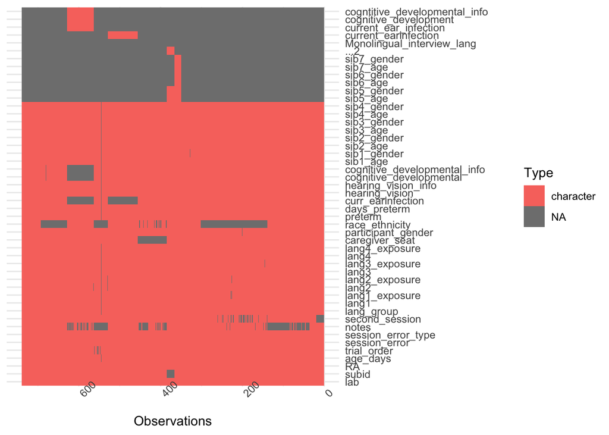

```r
pd_raw %>%
  vis_dat() +
  coord_flip()
```

```r
n_participant_rows = nrow(pd_raw)
n_unique_labs_from_participants = pd_raw %>%
  summarize(labs = n_distinct(lab))
unique_participants_by_lab = pd_raw %>%
  group_by(lab) %>%
  summarize(participants = n_distinct(subid))
```

Right after trial import, there are 739 rows in the pd_raw dataframe; this includes data from 15 labs. The number of participants coming from each lab is as follows:

```r
print(unique_participants_by_lab, n=1e4)
```

```
## # A tibble: 15 x 2
##    lab                     participants
##    <chr>                          <int>
##  1 babylab-brookes                  130
##  2 babylab-princeton                 35
##  3 Babylab-westernsydney             19
##  4 bll-umanitoba                     37
##  5 cdc-ceu                           32
##  6 elp-georgetown                    48
##  7 infantlanglab-utk                 18
##  8 irl-concordia                     38
##  9 koku_hamburg                      16
## 10 koku-hamburg                      18
## 11 LLL-Liv                           65
## 12 nusinfantlanguagecentre           71
## 13 UPF_Barcelona                     47
## 14 weltentdecker-zurich              64
## 15 wsu: kw                           48
```

# 4 Gazepath Data Import

```r
gazepath_files <- dir("processed_data/data_gazepath/", pattern = ".xlsx", all.files = FALSE)
gazepath_files <- paste0("processed_data/data_gazepath/", gazepath_files) # Adds path to names


for (file in gazepath_files){

  # if the merged dataset does exist, append to it
  if (exists("gp_raw")){
    temp_dataset <- read_excel(file, col_names=TRUE) %>%
     mutate_all(as.character)

gp_raw <- full_join(gp_raw, temp_dataset)
    rm(temp_dataset)
  }

  # if the merged dataset doesn't exist, create it
  if (!exists("gp_raw")){
       gp_raw <- read_excel(file, col_names=TRUE) %>%
       mutate_all(as.character)

  }

}

length(unique(gp_raw$lab))
```

```
## [1] 10
```

There are 10 lab ids that contributed eyetracking data. Note that here, koku-hamburg has two different ids. Will be handled in a later section

# 5 Handcoded Data Import

```r
handcoded_files <- dir("processed_data/handcoded_cleaned/", pattern = ".xlsx", all.files = FALSE)
handcoded_files <- paste0("processed_data/handcoded_cleaned/", handcoded_files) # Adds path to names


for (file in handcoded_files){

  # if the merged dataset does exist, append to it
  if (exists("hc_raw")){
    temp_dataset <- read_excel(file, col_names=TRUE) %>%
      mutate_all(as.character) %>%
      mutate_all(nc_na) %>%
      mutate(subid = as.character(subid)) %>%
      select(-contains("Note")) %>%
      {if("fixation_incongrent" %in% names(.)) rename(., fixation_incongruent=fixation_incongrent) else .} #https://stackoverflow.com/questions/34275576/avoiding-error-when-using-rename-in-dplyr-and-column-doesnt-exist

hc_raw <- full_join(hc_raw, temp_dataset)
    rm(temp_dataset)
  }

  # if the merged dataset doesn't exist, create it
  if (!exists("hc_raw")){
       hc_raw <- read_excel(file, col_names=TRUE) %>%
      mutate_all(as.character) %>%
      mutate_all(nc_na) %>%
      mutate(subid = as.character(subid)) %>%
      select(-contains("Note")) %>%
      {if("fixation_incongrent" %in% names(.)) rename(., fixation_incongruent=fixation_incongrent) else .}

  }

}

length(unique(hc_raw$lab))
```

```
## [1] 6
```

There are 6 labs that contributed hand-coded data. This includes on lab that also contributed eye-tracked data.

Join to get full dataset

```r
# Check if there are any repeated participants across hand coded and eyetracked data.  There are none
double_coded <- inner_join(gp_raw, hc_raw, by = c("lab", "subid"))

# Coding type

gp_raw$coding <- "gazepath"
hc_raw$coding <- "handcoding"

# Assume gazepath trials do not have an error

gp_raw$trial_error[is.na(gp_raw$trial_error)] <- "noerror"

# So join hand-coded and gazepath datasets
td_raw <- full_join(gp_raw, hc_raw)
```

```r
td <- td_raw %>%
  # Change variables to correct types
  mutate_if(is.character, tolower) %>%
  mutate_at(vars(study_order, trial_num, latency, n_shift_congruent, n_shift_incongruent, fixation_congruent, fixation_incongruent), as.numeric)
#  mutate_at(vars(lab, subid, first_shift, trial_error, trial_error_type, coding), as.factor)


# Fix video names
    td$stimulus = gsub("\\..*","", td$stimulus)
    td$stimulus = gsub("X", "", td$stimulus)

pd <- pd_raw %>%
  mutate_if(is.character, tolower)
 # mutate_at(vars(lab, subid, trial_order, session_error), as.factor)
```

See if lab ids are consistent, and if not fix them

```r
# Trials dataframe
td$lab[td$lab == "koku-hamburg_12-15mos"] <- "koku-hamburg"
td$lab[td$lab == "koku-hamburg_6-9mos"] <- "koku-hamburg"
td$lab[td$lab == "upf-barcelona"] <- "upf_barcelona"
td$lab[td$lab == "nus"] <- "nusinfantlanguagecentre"
td$lab[td$lab == "brookes-babylab"] <- "babylab-brookes"
td$lab[td$lab == "lll"] <- "lll-liv"
td$lab[td$lab == "zurich"] <- "weltentdecker-zurich"
td$lab[td$lab == "princeton-babylab"] <- "babylab-princeton"
td$lab[td$lab == "westernsydney-babylab"] <- "babylab-westernsydney"
td$lab[td$lab == "babylab_westernsydney"] <- "babylab-westernsydney"
td$lab[td$lab == "wsu: kw"] <- "babylab-westernsydney"

# Participants dataframe
pd$lab[pd$lab == "wsu: kw"] <- "babylab-westernsydney"
pd$lab[pd$lab == "babylab_westernsydney"] <- "babylab-westernsydney"
pd$lab[pd$lab == "koku_hamburg"] <- "koku-hamburg"
pd$lab[pd$lab == "princeton-babylab"] <- "babylab-princeton"


setdiff(unique(pd$lab), unique(td$lab))
```

```
## character(0)
```

```r
setdiff(unique(td$lab), unique(pd$lab))
```

```
## [1] NA
```

Correcting lab-specific subid issues and row issues

```r
# remove weird row with zero latency but no other info
td <- td %>%
  filter(!is.na(lab) & !is.na(subid) & !is.na(trial_num))


#irl-concordia trials
td$subid[td$lab == "irl-concordia" & td$subid == "gf_s30_47622"] <- "gf12_s30_47622" # correcting typo
td$subid[td$lab == "irl-concordia" & td$subid == "gf16_s19_46048"] <- "gf12_s19_46048" # correcting typo
td$subid[td$lab == "irl-concordia"] <- str_extract(td$subid[td$lab == "irl-concordia"], "gf[[:digit:]]+_s[[:digit:]]+")

#irl-concordia participants
pd$subid[pd$lab == "irl-concordia" & pd$age_days <= 300] <- paste0("gf6_", pd$subid[pd$lab == "irl-concordia" & pd$age_days <= 300])
pd$subid[pd$lab == "irl-concordia" & pd$age_days >= 300] <- paste0("gf12_", pd$subid[pd$lab == "irl-concordia" & pd$age_days >= 300])

#babylab-brookes
td$subid[td$lab == "babylab-brookes"] <- sub("g0", "g", td$subid[td$lab == "babylab-brookes"]) # Not all data zero-padded

#babylab-westernsydney trials
td$subid[td$lab == "babylab-westernsydney"] <- sub("mb00", "", td$subid[td$lab == "babylab-westernsydney"])
td$subid[td$lab == "babylab-westernsydney"] <- sub("mb0", "", td$subid[td$lab == "babylab-westernsydney"])
td$subid[td$lab == "babylab-westernsydney"] <- sub("mb", "", td$subid[td$lab == "babylab-westernsydney"])

#babylab-westernsydney participants
pd$subid[pd$lab == "babylab-westernsydney"] <- sub("mb00", "", pd$subid[pd$lab == "babylab-westernsydney"])
pd$subid[pd$lab == "babylab-westernsydney"] <- sub("mb0", "", pd$subid[pd$lab == "babylab-westernsydney"])
pd$subid[pd$lab == "babylab-westernsydney"] <- sub("mb", "", pd$subid[pd$lab == "babylab-westernsydney"])

#babylab-brookes
pd$subid[pd$lab == "babylab-brookes"] <- sub("g0", "g", pd$subid[pd$lab == "babylab-brookes"]) # Not all data zero-padded
```

# 6 Pre-merge Checking

```r
participants_premerge_td <- td %>%
  group_by(lab, subid) %>%
  summarize(trialcount = n_distinct(trial_num),
            rowcount = length(trial_num), trial_error = last(trial_error_type),present_td=TRUE)

participants_premerge_pd <- pd %>%
  group_by(lab, subid) %>%
  summarize(lines_in_pd = n(), age_days = first(age_days), notes = first(notes),days_preterm = first(days_preterm), session_error = first(session_error), session_error_type = first(session_error_type), notes = first(notes), present_pd=TRUE)

all_participants_premerge <- merge(participants_premerge_td, participants_premerge_pd, all.x=TRUE, all.y=TRUE) %>%
  replace_na(list(present_pd = FALSE, present_td=FALSE))

unmatched_participants_premerge <- filter(all_participants_premerge, !(present_td & present_pd)) %>%
  filter(session_error == "noerror")

# Check if we have resolved any of these issues

conf <- read_csv('metadata/true_unmatched_participants.csv') %>%
  filter(confirmed == 'X')%>%
  select(subid, lab, confirmed)

unmatched_participants_premerge <- merge(unmatched_participants_premerge, conf, all.x=TRUE) %>%
  replace_na(list(confirmed = FALSE))%>%
  filter(confirmed != 'X')

write_csv(unmatched_participants_premerge, 'metadata/unconfirmed_unmatched_participants.csv')

unmatched_participants_premerge
```

```
##                        lab      subid trialcount rowcount trial_error
## 1        infantlanglab-utk eg12_4m_s8         NA       NA        <NA>
## 2        infantlanglab-utk       <NA>         NA       NA        <NA>
## 3                  lll-liv      gf015         NA       NA        <NA>
## 4                  lll-liv      gf045         NA       NA        <NA>
## 5                  lll-liv       gfp1         NA       NA        <NA>
## 6                  lll-liv       gfp2         NA       NA        <NA>
## 7                  lll-liv       gfp3         NA       NA        <NA>
## 8  nusinfantlanguagecentre     mbg002         NA       NA        <NA>
## 9  nusinfantlanguagecentre     mbg003         NA       NA        <NA>
## 10 nusinfantlanguagecentre     mbg004         NA       NA        <NA>
## 11 nusinfantlanguagecentre     mbg013         NA       NA        <NA>
## 12 nusinfantlanguagecentre     ybg017         NA       NA        <NA>
## 13           upf_barcelona     subj01         NA       NA        <NA>
##    present_td lines_in_pd age_days
```

[output cut: 55 more lines]

```r
 #
 # participants_session_errors_all <- pd %>% filter(session_error!= "noerror") %>%
 #   select(lab, subid, session_error, session_error_type, notes) %>%
 #   filter(session_error != "na") %>%
 #   unique()
 #
 # write_csv(participants_session_errors_all, 'metadata/participants_session_errors_all.csv')


# participants_trial_errors_all <- td %>% filter(trial_error == "error")
#
# write_csv(participants_trial_errors_all, 'metadata/participants_trial_errors_all.csv')
```

# 7 Merge

Use `inner_join` to get matching participants. Our process is then to use testing to identify where we are missing participants in this join.

```r
d <- inner_join(td, pd)
```

# 8 Test Merge

```r
participants_postmerge <- d %>%
  group_by(lab, subid) %>%
  summarize(trialcount = n_distinct(trial_num),
            rowcount = length(trial_num))
```

Compare the number of rows and trials to pre-merge values! In the resulting dataframe, we have 19 participants missing from TD and 27 from PD. Where did they go, and why did they drop?

Here’s a full list of participants (and labs) who get lost during merge. Use `anti_join` to detect lost participants. (For sanity, this should be the same as the pre-merged list of ‘problem’ subids)

```r
lost_participants_td <- anti_join(participants_premerge_td, participants_postmerge)
lost_participants_pd <- anti_join(participants_premerge_pd, participants_postmerge)


validate_that(nrow(lost_participants_td) + nrow(lost_participants_pd) == nrow(unmatched_participants_premerge))
```

```
## [1] "nrow(lost_participants_td) + nrow(lost_participants_pd) not equal to nrow(unmatched_participants_premerge)"
```

```r
lost_participants_td
```

```
## # A tibble: 19 x 6
## # Groups:   lab [1]
##    lab               subid      trialcount rowcount trial_error present_td
##    <chr>             <chr>           <int>    <int> <chr>       <lgl>
##  1 infantlanglab-utk eg12_2m_s8          6        6 na          TRUE
##  2 infantlanglab-utk eg6_1f_s1           6        6 na          TRUE
##  3 infantlanglab-utk eg6_1m_s10          6        6 na          TRUE
##  4 infantlanglab-utk eg6_1m_s5           6        6 na          TRUE
##  5 infantlanglab-utk eg6_2f_s2           6        6 na          TRUE
##  6 infantlanglab-utk eg6_2m_s6           6        6 na          TRUE
##  7 infantlanglab-utk eg6_3f_s3           6        6 na          TRUE
##  8 infantlanglab-utk eg6_3m_s7           6        6 na          TRUE
##  9 infantlanglab-utk eg6_4f_s4           6        6 na          TRUE
## 10 infantlanglab-utk eg6_4f_s8           6        6 na          TRUE
## 11 infantlanglab-utk eg6_4m_s9           6        6 na          TRUE
## 12 infantlanglab-utk eg8_1f_s8           6        6 na          TRUE
## 13 infantlanglab-utk eg8_1m_s1           6        6 na          TRUE
## 14 infantlanglab-utk eg8_2f_s4           6        6 na          TRUE
## 15 infantlanglab-utk eg8_2m_s2           6        6 na          TRUE
## 16 infantlanglab-utk eg8_3f_s5           6        6 na          TRUE
## 17 infantlanglab-utk eg8_3m-s3           6        6 na          TRUE
## 18 infantlanglab-utk eg8_4f_s6           6        6 na          TRUE
## 19 infantlanglab-utk eg8_4m_s7           6        6 na          TRUE
```

```r
lost_participants_pd
```

```
## # A tibble: 27 x 9
## # Groups:   lab [6]
##    lab   subid lines_in_pd age_days notes days_preterm session_error
##    <chr> <chr>       <int> <chr>    <chr> <chr>        <chr>
##  1 infa… <NA>           18 225      did … 20           noerror
##  2 infa… eg12…           1 387      did … na           noerror
##  3 koku… mb_0…           1 384      <NA>  na           error
##  4 koku… mb_1…           1 434      <NA>  na           error
##  5 koku… mb_1…           1 <NA>     <NA>  <NA>         error
##  6 koku… mb_1…           1 214      <NA>  na           error
##  7 koku… mb_2…           1 235      <NA>  na           error
##  8 koku… mb_2…           1 200      <NA>  na           error
##  9 koku… mb_2…           1 256      <NA>  na           error
## 10 koku… mb_3…           1 272      <NA>  na           error
## # … with 17 more rows, and 2 more variables: session_error_type <chr>,
## #   present_pd <lgl>
```

# 9 Output

Output intermediate files.

```r
write_csv(d, "processed_data/01_merged_output.csv")
```